# Using R language in microbiome analysis

## To install all the required R packages for this project

To install most of the required R packages for this project at once using a saved list of R packages.

[output not shown]

[output cut: 12 more lines]

```
devtools::install_github("zdk123/SpiecEasi")
devtools::install_github("fjossandon/Tax4Fun2")
devtools::install_github("kylebittinger/qiimer")
devtools::install_github("joey711/biom",upgrade = "never",force = TRUE)
install.packages("./install.packages.for.local/Tax4Fun/", repos = NULL, type = "source")
devtools::install_github("xia-lab/MicrobiomeAnalystR",
                         build = TRUE,
                         build_opts = c("--no-resave-data", "--no-manual"))

install.packages("./install.packages.for.local/ggtern/", repos = NULL, type = "source")
# Error: Failed to install 'ggtern' from GitHub:
#   ! System command 'Rcmd.exe' failed
remotes::install_github("https://github.com/xielab2017/EasyMicroPlot",
                        subdir='Version_0.5')
install.packages("microeco")
```

## Contents

### Before microbiome data analysis

- 1.Before microbiome data analysis/Code1A-2H.Rmd

### Microbial community analysis

- 2.Microbial community analysis/Code3A-8E.Rmd

### Integrated R packages for microbiome

- 3.Integrated R packages for microbiome/Pipeline1-6/01.phyloseq/pipeline.1.phyloseq.Rmd
- 3.Integrated R packages for microbiome/Pipeline1-6/02.microbiome/pipeline.2.microbiome.Rmd
- 3.Integrated R packages for microbiome/Pipeline1-6/03.MicrobiomeAnalystR/pipeline.2.microbiome.Rmd
- 3.Integrated R packages for microbiome/Pipeline1-6/04.animalcules/pipeline.2.microbiome.Rmd
- 3.Integrated R packages for microbiome/Pipeline1-6/05.microeco/pipeline.2.microbiome.Rmd
- 3.Integrated R packages for microbiome/Pipeline1-6/06.EasyAmplicon/pipeline.6.Amplicon.Rmd

### The best practice R pipeline

- 4.The best practice R pipeline/Pipeline.BestPractice.Rmd

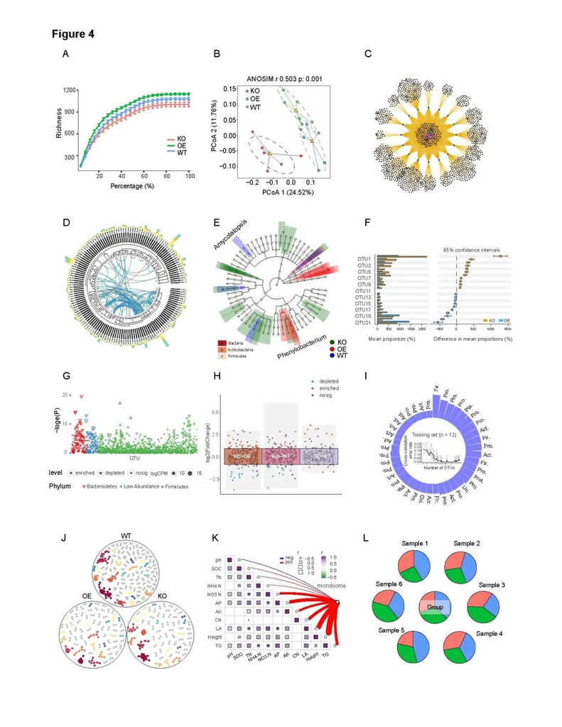

image

## Other results that can be obtained from running this project can be displayed

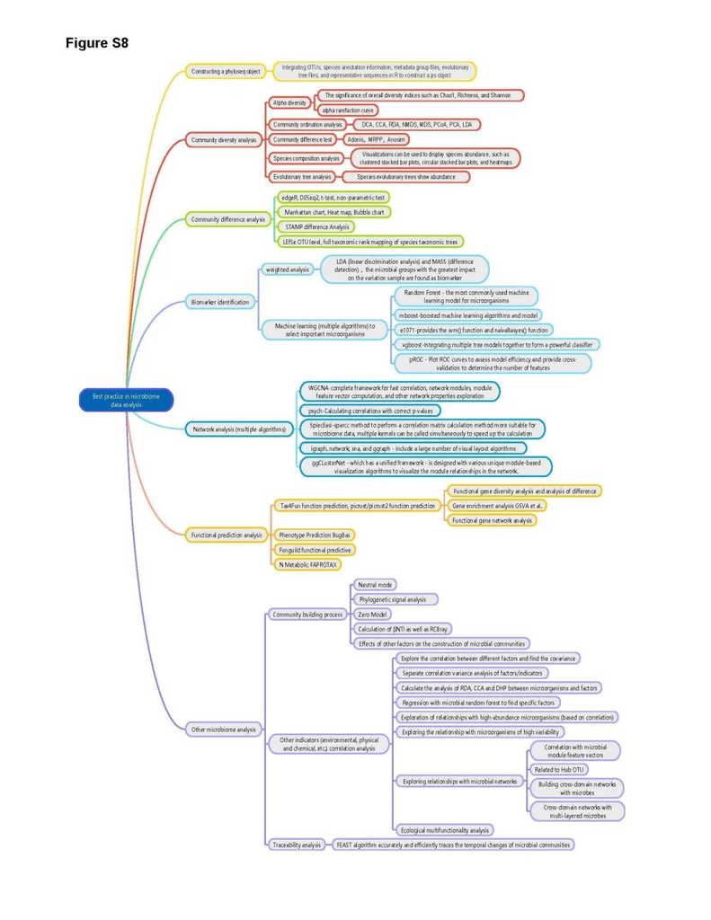

image

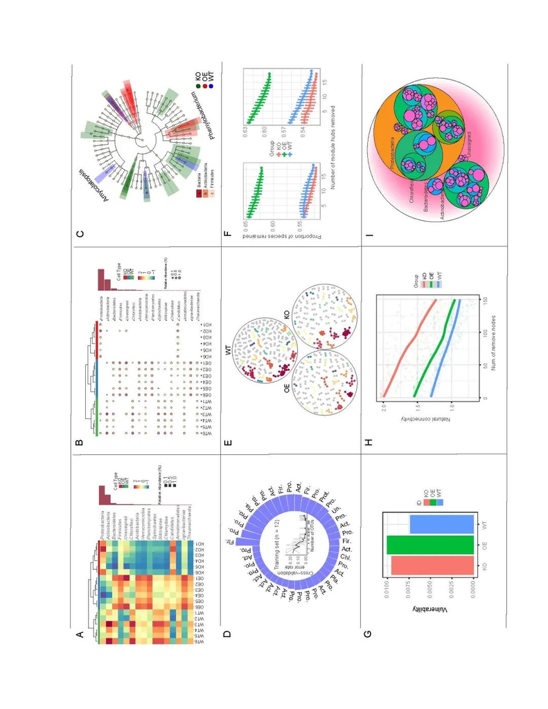

image

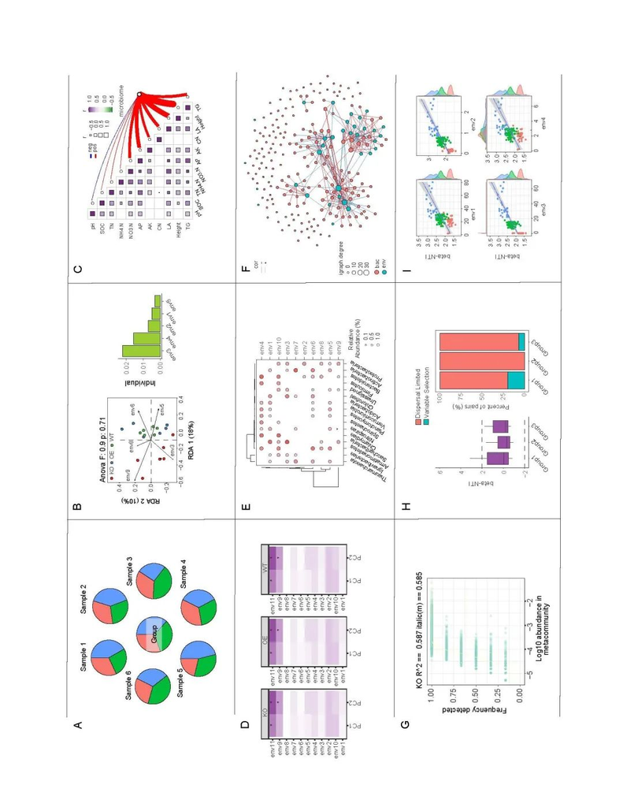

image

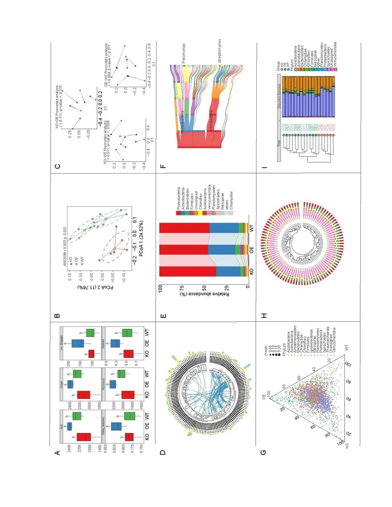

image

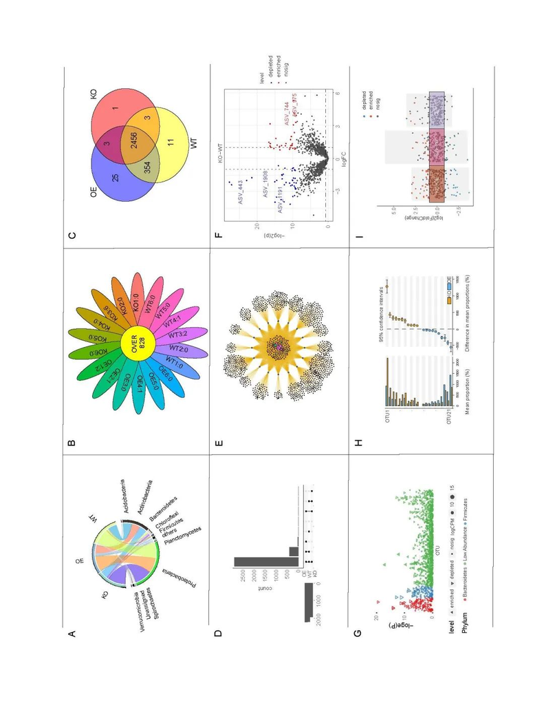

image

## reference

Wen, T., G. Niu, T. Chen, Q. Shen, J. Yuan and Y. X. Liu (2023). “The best practice for microbiome analysis using R.” Protein Cell. https://doi.org/10.1093/procel/pwad024.